# CQNU-TED （基于Django的在线学习平台）

[figure not shown]

[figure not shown]

[figure not shown]

[figure not shown]

[figure not shown]

## 目录

### 1. 开发意义

### 2. 技术架构

### 3. 平台特点

### 4. Demo展示

### 5. 后续工作

## 开发意义

### 1. 基于在线个性化学习的需求。慕课网因为种类繁杂，学生并不能根据专业知识需要找到自己的课程学习，并且每所高校教师基本都具有自己的一套学习体系，课堂结束后需要能够上传资料供学生学习的平台（逐步替代QQ群）。

### 2. 推进校园教学智慧化进程。通过对课程数字化，结合先进的深度学习技术提高学习效率，通过机器推荐和完成课前线上学习任务，给老师减少教学负担,提高老师教学的效率。

## 技术架构

##### Django是一个开放源代码的Web应用框架，完全由Python写成。采用了MVT的软件设计模式，即模型Model，视图View和模板Template便于快速建站，本次系统采用Django+Mysql的组合，后续将支持TensorFlow等机器学习框架。

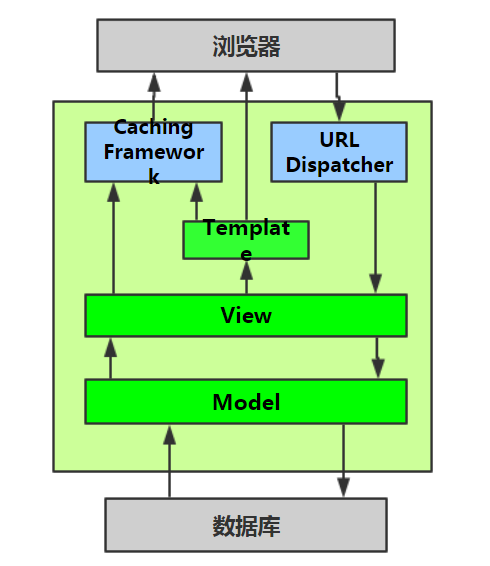

## 平台特点

### 1. 不局限于老师，有想法的学生都可以申请和提交作品，知识共享。

[figure not shown]

### 2. 简化数据库操作，使用Model层映射，运维无需直接对数据库操作。

[figure not shown]

### 3. 集合视频、PPT、文档、站外链接等多种形式的学习资料。

[figure not shown]

## Demo展示

### [点击演示demo](http://127.0.0.1:8000/)

## 后续工作

#### 1. 购买服务器之后，尽快完成线下测试，并上线使用。

#### 1. 后续加入实时人脸识别，对听课状态进行检测和记录。

#### 2. 对评论文本进行主题和情感分析，挖掘平台意见。

#### 3. 加入基于机器学习的推荐策略，不再使用统计策略，实现个性化推荐。

## 数据分析样例

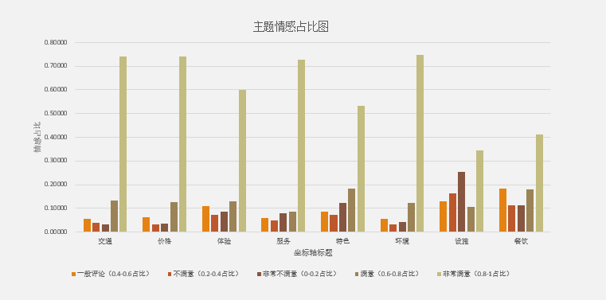